# Risk Factor Analysis

## Outcome Variable

**Outcome Variable:** sstunted

## Predictor Variables

**Intervention Variable:** hfoodsec

**Adjustment Set:**

- arm
- sex
- W_mage
- meducyrs
- feducyrs
- hhwealth_quart
- vagbrth
- W_nrooms
- W_nchldlt5
- brthmon
- W_parity
- impfloor
- impsan
- safeh20
- delta_W_mage
- delta_meducyrs
- delta_feducyrs
- delta_hhwealth_quart
- delta_vagbrth
- delta_W_nrooms
- delta_W_nchldlt5
- delta_brthmon
- delta_W_parity
- delta_impfloor
- delta_impsan
- delta_safeh20

## Stratifying Variables

The analysis was stratified on these variable(s):

- agecat
- studyid
- country

## Data Summary

| agecat | studyid | country | hfoodsec | sstunted | n_cell | n |
| --- | --- | --- | --- | --- | --- | --- |
| Birth | GMS-Nepal | NEPAL | Food Secure | 0 | 460 | 672 |
| Birth | GMS-Nepal | NEPAL | Food Secure | 1 | 17 | 672 |
| Birth | GMS-Nepal | NEPAL | Mildly Food Insecure | 0 | 101 | 672 |
| Birth | GMS-Nepal | NEPAL | Mildly Food Insecure | 1 | 5 | 672 |
| Birth | GMS-Nepal | NEPAL | Food Insecure | 0 | 81 | 672 |
| Birth | GMS-Nepal | NEPAL | Food Insecure | 1 | 8 | 672 |
| Birth | JiVitA-3 | BANGLADESH | Food Secure | 0 | 6342 | 14364 |
| Birth | JiVitA-3 | BANGLADESH | Food Secure | 1 | 609 | 14364 |
| Birth | JiVitA-3 | BANGLADESH | Mildly Food Insecure | 0 | 4381 | 14364 |
| Birth | JiVitA-3 | BANGLADESH | Mildly Food Insecure | 1 | 496 | 14364 |
| Birth | JiVitA-3 | BANGLADESH | Food Insecure | 0 | 2258 | 14364 |
| Birth | JiVitA-3 | BANGLADESH | Food Insecure | 1 | 278 | 14364 |
| Birth | JiVitA-4 | BANGLADESH | Food Secure | 0 | 1304 | 2810 |
| Birth | JiVitA-4 | BANGLADESH | Food Secure | 1 | 129 | 2810 |
| Birth | JiVitA-4 | BANGLADESH | Mildly Food Insecure | 0 | 941 | 2810 |
| Birth | JiVitA-4 | BANGLADESH | Mildly Food Insecure | 1 | 77 | 2810 |
| Birth | JiVitA-4 | BANGLADESH | Food Insecure | 0 | 332 | 2810 |
| Birth | JiVitA-4 | BANGLADESH | Food Insecure | 1 | 27 | 2810 |
| Birth | MAL-ED | BANGLADESH | Food Secure | 0 | 140 | 172 |
| Birth | MAL-ED | BANGLADESH | Food Secure | 1 | 4 | 172 |
| Birth | MAL-ED | BANGLADESH | Mildly Food Insecure | 0 | 3 | 172 |
| Birth | MAL-ED | BANGLADESH | Mildly Food Insecure | 1 | 1 | 172 |
| Birth | MAL-ED | BANGLADESH | Food Insecure | 0 | 23 | 172 |
| Birth | MAL-ED | BANGLADESH | Food Insecure | 1 | 1 | 172 |
| Birth | MAL-ED | BRAZIL | Food Secure | 0 | 0 | 28 |
| Birth | MAL-ED | BRAZIL | Food Secure | 1 | 0 | 28 |
| Birth | MAL-ED | BRAZIL | Mildly Food Insecure | 0 | 4 | 28 |
| Birth | MAL-ED | BRAZIL | Mildly Food Insecure | 1 | 0 | 28 |
| Birth | MAL-ED | BRAZIL | Food Insecure | 0 | 22 | 28 |
| Birth | MAL-ED | BRAZIL | Food Insecure | 1 | 2 | 28 |

[output cut: 168 more lines]

The following strata were considered:

- agecat: 24 months, studyid: GMS-Nepal, country: NEPAL
- agecat: 24 months, studyid: JiVitA-3, country: BANGLADESH
- agecat: 24 months, studyid: JiVitA-4, country: BANGLADESH
- agecat: 24 months, studyid: MAL-ED, country: BANGLADESH
- agecat: 24 months, studyid: MAL-ED, country: BRAZIL
- agecat: 24 months, studyid: MAL-ED, country: INDIA
- agecat: 24 months, studyid: MAL-ED, country: NEPAL
- agecat: 24 months, studyid: MAL-ED, country: PERU
- agecat: 24 months, studyid: MAL-ED, country: SOUTH AFRICA
- agecat: 24 months, studyid: NIH-Birth, country: BANGLADESH
- agecat: 24 months, studyid: NIH-Crypto, country: BANGLADESH
- agecat: 6 months, studyid: GMS-Nepal, country: NEPAL
- agecat: 6 months, studyid: JiVitA-3, country: BANGLADESH
- agecat: 6 months, studyid: JiVitA-4, country: BANGLADESH
- agecat: 6 months, studyid: MAL-ED, country: BANGLADESH
- agecat: 6 months, studyid: MAL-ED, country: BRAZIL
- agecat: 6 months, studyid: MAL-ED, country: INDIA
- agecat: 6 months, studyid: MAL-ED, country: NEPAL
- agecat: 6 months, studyid: MAL-ED, country: PERU
- agecat: 6 months, studyid: MAL-ED, country: SOUTH AFRICA
- agecat: 6 months, studyid: NIH-Birth, country: BANGLADESH
- agecat: 6 months, studyid: NIH-Crypto, country: BANGLADESH
- agecat: Birth, studyid: GMS-Nepal, country: NEPAL
- agecat: Birth, studyid: JiVitA-3, country: BANGLADESH
- agecat: Birth, studyid: JiVitA-4, country: BANGLADESH
- agecat: Birth, studyid: MAL-ED, country: BANGLADESH
- agecat: Birth, studyid: MAL-ED, country: BRAZIL
- agecat: Birth, studyid: MAL-ED, country: INDIA
- agecat: Birth, studyid: MAL-ED, country: NEPAL
- agecat: Birth, studyid: MAL-ED, country: PERU
- agecat: Birth, studyid: MAL-ED, country: SOUTH AFRICA
- agecat: Birth, studyid: NIH-Birth, country: BANGLADESH
- agecat: Birth, studyid: NIH-Crypto, country: BANGLADESH

### Dropped Strata

Some strata were dropped due to rare outcomes:

- agecat: Birth, studyid: MAL-ED, country: BANGLADESH
- agecat: Birth, studyid: MAL-ED, country: BRAZIL
- agecat: Birth, studyid: MAL-ED, country: INDIA
- agecat: Birth, studyid: MAL-ED, country: NEPAL
- agecat: Birth, studyid: MAL-ED, country: PERU
- agecat: Birth, studyid: MAL-ED, country: SOUTH AFRICA
- agecat: Birth, studyid: NIH-Birth, country: BANGLADESH
- agecat: Birth, studyid: NIH-Crypto, country: BANGLADESH
- agecat: 6 months, studyid: GMS-Nepal, country: NEPAL
- agecat: 6 months, studyid: MAL-ED, country: BANGLADESH
- agecat: 6 months, studyid: MAL-ED, country: BRAZIL
- agecat: 6 months, studyid: MAL-ED, country: INDIA
- agecat: 6 months, studyid: MAL-ED, country: NEPAL
- agecat: 6 months, studyid: MAL-ED, country: PERU
- agecat: 6 months, studyid: MAL-ED, country: SOUTH AFRICA
- agecat: 6 months, studyid: NIH-Birth, country: BANGLADESH
- agecat: 6 months, studyid: NIH-Crypto, country: BANGLADESH
- agecat: 24 months, studyid: MAL-ED, country: BANGLADESH
- agecat: 24 months, studyid: MAL-ED, country: BRAZIL
- agecat: 24 months, studyid: MAL-ED, country: INDIA
- agecat: 24 months, studyid: MAL-ED, country: NEPAL
- agecat: 24 months, studyid: MAL-ED, country: PERU
- agecat: 24 months, studyid: MAL-ED, country: SOUTH AFRICA

## Methods Detail

We’re interested in the causal parameters $E[Y_a]$ for all values of $a \in \mathcal{A}$. These parameters represent the mean outcome if, possibly contrary to fact, we intervened to set all units to have $A=a$. Under the randomization and positivity assumptions, these are identified by the statistical parameters $\psi_a=E_W[E_{Y|A,W}(Y|A=a,W)]$. In addition, we’re interested in the mean of $Y$, $E[Y]$ under no intervention (the observed mean). We will estimate these parameters by using SuperLearner to fit the relevant likelihood factors – $E_{Y|A,W}(Y|A=a,W)$ and $p(A=a|W)$, and then updating our likelihood fit using a joint TMLE.

For unadjusted analyses ($W=\{\}$), initial likelihoods were estimated using Lrnr_glm to estimate the simple $E(Y|A)$ and Lrnr_mean to estimate $p(A)$. For adjusted analyses, a small library containing Lrnr_glmnet, Lrnr_xgboost, and Lrnr_mean was used.

Having estimated these parameters, we will then use the delta method to estimate relative risks and attributable risks relative to a prespecified baseline level of $A$.

# Results Detail

## Results Plots

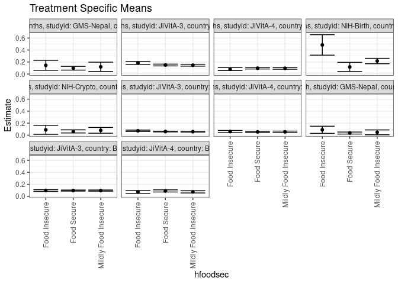

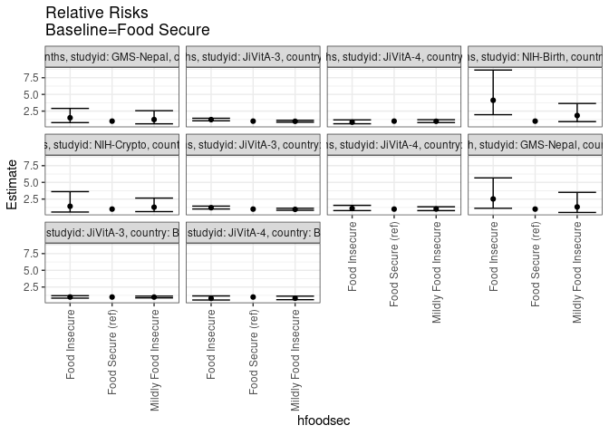

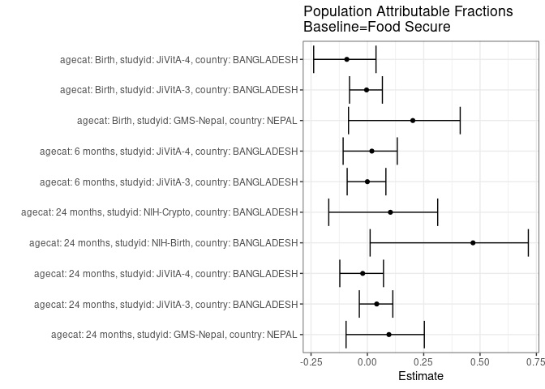

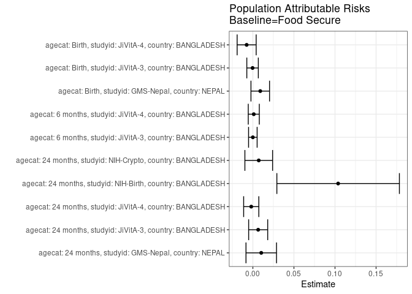

## Results Table

### Parameter: TSM

| agecat | studyid | country | intervention_level | baseline_level | estimate | ci_lower | ci_upper |
| --- | --- | --- | --- | --- | --- | --- | --- |
| Birth | GMS-Nepal | NEPAL | Food Secure | NA | 0.0356394 | 0.0189901 | 0.0522888 |
| Birth | GMS-Nepal | NEPAL | Mildly Food Insecure | NA | 0.0471698 | 0.0067813 | 0.0875584 |
| Birth | GMS-Nepal | NEPAL | Food Insecure | NA | 0.0898876 | 0.0304209 | 0.1493544 |
| Birth | JiVitA-3 | BANGLADESH | Food Secure | NA | 0.0966324 | 0.0879484 | 0.1053164 |
| Birth | JiVitA-3 | BANGLADESH | Mildly Food Insecure | NA | 0.0961653 | 0.0864983 | 0.1058323 |
| Birth | JiVitA-3 | BANGLADESH | Food Insecure | NA | 0.0969196 | 0.0821247 | 0.1117146 |
| Birth | JiVitA-4 | BANGLADESH | Food Secure | NA | 0.0904859 | 0.0725494 | 0.1084224 |
| Birth | JiVitA-4 | BANGLADESH | Mildly Food Insecure | NA | 0.0748852 | 0.0564155 | 0.0933549 |
| Birth | JiVitA-4 | BANGLADESH | Food Insecure | NA | 0.0729553 | 0.0504005 | 0.0955101 |
| 6 months | JiVitA-3 | BANGLADESH | Food Secure | NA | 0.0606926 | 0.0542074 | 0.0671778 |
| 6 months | JiVitA-3 | BANGLADESH | Mildly Food Insecure | NA | 0.0582588 | 0.0515283 | 0.0649894 |
| 6 months | JiVitA-3 | BANGLADESH | Food Insecure | NA | 0.0733613 | 0.0625405 | 0.0841821 |
| 6 months | JiVitA-4 | BANGLADESH | Food Secure | NA | 0.0548017 | 0.0458462 | 0.0637572 |
| 6 months | JiVitA-4 | BANGLADESH | Mildly Food Insecure | NA | 0.0557216 | 0.0432772 | 0.0681661 |
| 6 months | JiVitA-4 | BANGLADESH | Food Insecure | NA | 0.0602884 | 0.0420024 | 0.0785743 |
| 24 months | GMS-Nepal | NEPAL | Food Secure | NA | 0.0964912 | 0.0651656 | 0.1278169 |
| 24 months | GMS-Nepal | NEPAL | Mildly Food Insecure | NA | 0.1194030 | 0.0416778 | 0.1971281 |
| 24 months | GMS-Nepal | NEPAL | Food Insecure | NA | 0.1449275 | 0.0617789 | 0.2280762 |
| 24 months | JiVitA-3 | BANGLADESH | Food Secure | NA | 0.1498418 | 0.1348604 | 0.1648231 |
| 24 months | JiVitA-3 | BANGLADESH | Mildly Food Insecure | NA | 0.1465050 | 0.1308991 | 0.1621108 |
| 24 months | JiVitA-3 | BANGLADESH | Food Insecure | NA | 0.1838310 | 0.1604753 | 0.2071868 |
| 24 months | JiVitA-4 | BANGLADESH | Food Secure | NA | 0.0970352 | 0.0832326 | 0.1108379 |
| 24 months | JiVitA-4 | BANGLADESH | Mildly Food Insecure | NA | 0.0949470 | 0.0793384 | 0.1105557 |
| 24 months | JiVitA-4 | BANGLADESH | Food Insecure | NA | 0.0822182 | 0.0573402 | 0.1070962 |
| 24 months | NIH-Birth | BANGLADESH | Food Secure | NA | 0.1176471 | 0.0409794 | 0.1943147 |
| 24 months | NIH-Birth | BANGLADESH | Mildly Food Insecure | NA | 0.2164634 | 0.1718424 | 0.2610845 |
| 24 months | NIH-Birth | BANGLADESH | Food Insecure | NA | 0.4848485 | 0.3141348 | 0.6555622 |
| 24 months | NIH-Crypto | BANGLADESH | Food Secure | NA | 0.0628743 | 0.0368167 | 0.0889318 |
| 24 months | NIH-Crypto | BANGLADESH | Mildly Food Insecure | NA | 0.0806452 | 0.0326728 | 0.1286175 |
| 24 months | NIH-Crypto | BANGLADESH | Food Insecure | NA | 0.0892857 | 0.0145275 | 0.1640439 |

### Parameter: E(Y)

| agecat | studyid | country | intervention_level | baseline_level | estimate | ci_lower | ci_upper |
| --- | --- | --- | --- | --- | --- | --- | --- |
| Birth | GMS-Nepal | NEPAL | NA | NA | 0.0446429 | 0.0290169 | 0.0602688 |
| Birth | JiVitA-3 | BANGLADESH | NA | NA | 0.0962824 | 0.0908494 | 0.1017154 |
| Birth | JiVitA-4 | BANGLADESH | NA | NA | 0.0829181 | 0.0711515 | 0.0946848 |
| 6 months | JiVitA-3 | BANGLADESH | NA | NA | 0.0606873 | 0.0568242 | 0.0645503 |
| 6 months | JiVitA-4 | BANGLADESH | NA | NA | 0.0559149 | 0.0491257 | 0.0627040 |
| 24 months | GMS-Nepal | NEPAL | NA | NA | 0.1066946 | 0.0789894 | 0.1343997 |
| 24 months | JiVitA-3 | BANGLADESH | NA | NA | 0.1563185 | 0.1472145 | 0.1654224 |
| 24 months | JiVitA-4 | BANGLADESH | NA | NA | 0.0950562 | 0.0854670 | 0.1046455 |
| 24 months | NIH-Birth | BANGLADESH | NA | NA | 0.2214452 | 0.1821080 | 0.2607825 |
| 24 months | NIH-Crypto | BANGLADESH | NA | NA | 0.0700389 | 0.0479542 | 0.0921236 |

### Parameter: RR

| agecat | studyid | country | intervention_level | baseline_level | estimate | ci_lower | ci_upper |
| --- | --- | --- | --- | --- | --- | --- | --- |
| Birth | GMS-Nepal | NEPAL | Food Secure | Food Secure | 1.0000000 | 1.0000000 | 1.000000 |
| Birth | GMS-Nepal | NEPAL | Mildly Food Insecure | Food Secure | 1.3235294 | 0.4990314 | 3.510260 |
| Birth | GMS-Nepal | NEPAL | Food Insecure | Food Secure | 2.5221414 | 1.1221261 | 5.668880 |
| Birth | JiVitA-3 | BANGLADESH | Food Secure | Food Secure | 1.0000000 | 1.0000000 | 1.000000 |
| Birth | JiVitA-3 | BANGLADESH | Mildly Food Insecure | Food Secure | 0.9951662 | 0.8726767 | 1.134848 |
| Birth | JiVitA-3 | BANGLADESH | Food Insecure | Food Secure | 1.0029725 | 0.8401860 | 1.197299 |
| Birth | JiVitA-4 | BANGLADESH | Food Secure | Food Secure | 1.0000000 | 1.0000000 | 1.000000 |
| Birth | JiVitA-4 | BANGLADESH | Mildly Food Insecure | Food Secure | 0.8275899 | 0.6032295 | 1.135397 |
| Birth | JiVitA-4 | BANGLADESH | Food Insecure | Food Secure | 0.8062616 | 0.5571952 | 1.166661 |
| 6 months | JiVitA-3 | BANGLADESH | Food Secure | Food Secure | 1.0000000 | 1.0000000 | 1.000000 |
| 6 months | JiVitA-3 | BANGLADESH | Mildly Food Insecure | Food Secure | 0.9599007 | 0.8242498 | 1.117876 |
| 6 months | JiVitA-3 | BANGLADESH | Food Insecure | Food Secure | 1.2087360 | 1.0124446 | 1.443084 |
| 6 months | JiVitA-4 | BANGLADESH | Food Secure | Food Secure | 1.0000000 | 1.0000000 | 1.000000 |
| 6 months | JiVitA-4 | BANGLADESH | Mildly Food Insecure | Food Secure | 1.0167865 | 0.7711578 | 1.340653 |
| 6 months | JiVitA-4 | BANGLADESH | Food Insecure | Food Secure | 1.1001180 | 0.7772162 | 1.557172 |
| 24 months | GMS-Nepal | NEPAL | Food Secure | Food Secure | 1.0000000 | 1.0000000 | 1.000000 |
| 24 months | GMS-Nepal | NEPAL | Mildly Food Insecure | Food Secure | 1.2374491 | 0.5978826 | 2.561172 |
| 24 months | GMS-Nepal | NEPAL | Food Insecure | Food Secure | 1.5019763 | 0.7769123 | 2.903716 |
| 24 months | JiVitA-3 | BANGLADESH | Food Secure | Food Secure | 1.0000000 | 1.0000000 | 1.000000 |
| 24 months | JiVitA-3 | BANGLADESH | Mildly Food Insecure | Food Secure | 0.9777311 | 0.8474492 | 1.128042 |
| 24 months | JiVitA-3 | BANGLADESH | Food Insecure | Food Secure | 1.2268343 | 1.0526315 | 1.429866 |
| 24 months | JiVitA-4 | BANGLADESH | Food Secure | Food Secure | 1.0000000 | 1.0000000 | 1.000000 |
| 24 months | JiVitA-4 | BANGLADESH | Mildly Food Insecure | Food Secure | 0.9784799 | 0.7895528 | 1.212614 |
| 24 months | JiVitA-4 | BANGLADESH | Food Insecure | Food Secure | 0.8473028 | 0.6062206 | 1.184259 |
| 24 months | NIH-Birth | BANGLADESH | Food Secure | Food Secure | 1.0000000 | 1.0000000 | 1.000000 |
| 24 months | NIH-Birth | BANGLADESH | Mildly Food Insecure | Food Secure | 1.8399390 | 0.9288873 | 3.644549 |
| 24 months | NIH-Birth | BANGLADESH | Food Insecure | Food Secure | 4.1212121 | 1.9648904 | 8.643937 |
| 24 months | NIH-Crypto | BANGLADESH | Food Secure | Food Secure | 1.0000000 | 1.0000000 | 1.000000 |
| 24 months | NIH-Crypto | BANGLADESH | Mildly Food Insecure | Food Secure | 1.2826421 | 0.6212197 | 2.648291 |
| 24 months | NIH-Crypto | BANGLADESH | Food Insecure | Food Secure | 1.4200680 | 0.5579185 | 3.614494 |

### Parameter: PAR

| agecat | studyid | country | intervention_level | baseline_level | estimate | ci_lower | ci_upper |
| --- | --- | --- | --- | --- | --- | --- | --- |
| Birth | GMS-Nepal | NEPAL | Food Secure | NA | 0.0090034 | -0.0023034 | 0.0203103 |
| Birth | JiVitA-3 | BANGLADESH | Food Secure | NA | -0.0003500 | -0.0073598 | 0.0066597 |
| Birth | JiVitA-4 | BANGLADESH | Food Secure | NA | -0.0075677 | -0.0191518 | 0.0040163 |
| 6 months | JiVitA-3 | BANGLADESH | Food Secure | NA | -0.0000053 | -0.0052137 | 0.0052031 |
| 6 months | JiVitA-4 | BANGLADESH | Food Secure | NA | 0.0011132 | -0.0056045 | 0.0078308 |
| 24 months | GMS-Nepal | NEPAL | Food Secure | NA | 0.0102033 | -0.0083620 | 0.0287687 |
| 24 months | JiVitA-3 | BANGLADESH | Food Secure | NA | 0.0064767 | -0.0051103 | 0.0180637 |
| 24 months | JiVitA-4 | BANGLADESH | Food Secure | NA | -0.0019790 | -0.0111899 | 0.0072319 |
| 24 months | NIH-Birth | BANGLADESH | Food Secure | NA | 0.1037982 | 0.0292197 | 0.1783766 |
| 24 months | NIH-Crypto | BANGLADESH | Food Secure | NA | 0.0071647 | -0.0096965 | 0.0240259 |

### Parameter: PAF

| agecat | studyid | country | intervention_level | baseline_level | estimate | ci_lower | ci_upper |
| --- | --- | --- | --- | --- | --- | --- | --- |
| Birth | GMS-Nepal | NEPAL | Food Secure | NA | 0.2016771 | -0.0837182 | 0.4119141 |
| Birth | JiVitA-3 | BANGLADESH | Food Secure | NA | -0.0036355 | -0.0791551 | 0.0665993 |
| Birth | JiVitA-4 | BANGLADESH | Food Secure | NA | -0.0912677 | -0.2383315 | 0.0383308 |
| 6 months | JiVitA-3 | BANGLADESH | Food Secure | NA | -0.0000872 | -0.0897016 | 0.0821576 |
| 6 months | JiVitA-4 | BANGLADESH | Food Secure | NA | 0.0199081 | -0.1076028 | 0.1327396 |
| 24 months | GMS-Nepal | NEPAL | Food Secure | NA | 0.0956312 | -0.0945510 | 0.2527686 |
| 24 months | JiVitA-3 | BANGLADESH | Food Secure | NA | 0.0414328 | -0.0357655 | 0.1128773 |
| 24 months | JiVitA-4 | BANGLADESH | Food Secure | NA | -0.0208194 | -0.1223129 | 0.0714958 |
| 24 months | NIH-Birth | BANGLADESH | Food Secure | NA | 0.4687307 | 0.0121611 | 0.7142782 |
| 24 months | NIH-Crypto | BANGLADESH | Food Secure | NA | 0.1022954 | -0.1713644 | 0.3120215 |